Saltar al contenido principal

# ¿El suelo es un organismo vivo?

Cómo las prácticas de recuperación del suelo pueden aumentar la fauna edáfica

Autor/a

Mariana dos Santos Moreno

Fecha de publicación

10 de noviembre de 2026

Clase para el curso *Conservación del Suelo y Gestión del Carbono* (REN237-1), Pontificia Universidad Católica de Chile.

## Introducción

100.000

En un solo metro cuadrado de suelo puede haber hasta 100.000 ácaros (FAO et al., 2020) y, en la mayoría de los ecosistemas terrestres, entre 10.000 y 100.000 colémbolos (FAO et al., 2020). Y si contamos a todos los organismos, un metro cuadrado de suelo rico puede albergar hasta mil millones (Britannica Editors, s. f.). ¿Qué hace que estas cifras suban o bajen?

El recorrido tiene cinco partes:

1. ¿Qué hay en el suelo?
2. ¿Qué hacen sus organismos?
3. ¿Cómo sabemos si el suelo está sano?
4. El suelo en el Antropoceno
5. Actividad: detectives del suelo

## 1. ¿Qué hay en el suelo?

> “La importancia de los infinitamente pequeños es infinitamente grande”.  
> - Louis Pasteur (1822–1895)

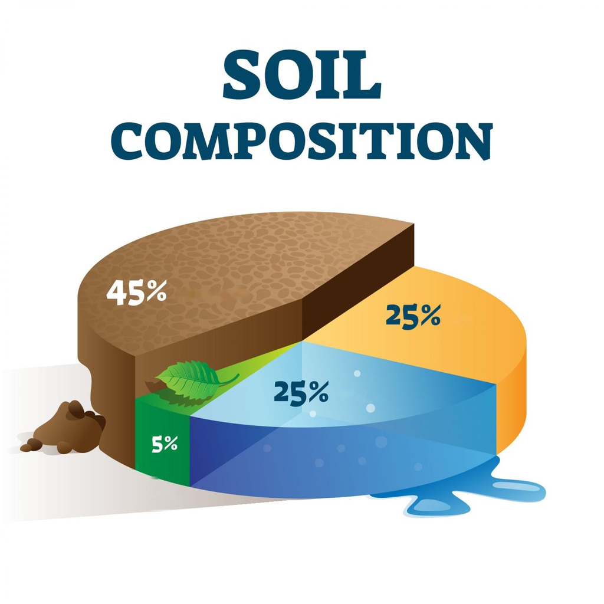

Composición aproximada de un suelo (Australian Environmental Education, 2026).

Alrededor del 5 % del volumen de un suelo es materia orgánica, viva y muerta:

- **Viva (biota del suelo):** raíces de las plantas; microorganismos como bacterias, hongos y algas; y fauna (micro, meso y macrofauna).
- **Muerta:** restos frescos como hojas, raíces y animales muertos (hojarasca); materia orgánica particulada, es decir, fragmentos en descomposición; y humus y materia orgánica unida a los minerales, la fracción más estable.

La parte viva transforma la muerta: la fauna fragmenta la hojarasca y los microbios la descomponen, liberan nutrientes y CO<sub>2</sub>, y una parte queda en el suelo como materia orgánica (Baretta et al., 2011; Chenu et al., 2015).

### Los organismos del suelo

**Código**

```
flowchart TD
  O(Organismos del suelo) --> F("Animales (fauna)")
  O --> V("Vegetales (flora)")
  F --> MA(Macrofauna)
  F --> ME(Mesofauna)
  F --> MI(Microfauna)
  V --> MF(Macroflora)
  V --> MIF(Microbiota)
  classDef default fill:#EFE3CF,stroke:none,color:#4A3A2A,rx:12,ry:12
  linkStyle default stroke:#A8875F,stroke-width:2px
```

[output not shown]

Clasificación clásica de los organismos del suelo (Baretta et al., 2011).

La clasificación más usada es la de Swift et al. (1979): por tamaño, pero también por movilidad, hábito alimentario y función. Los límites cambian según el autor; Lavelle et al. (1994), por ejemplo, extienden la mesofauna hasta 4 mm.

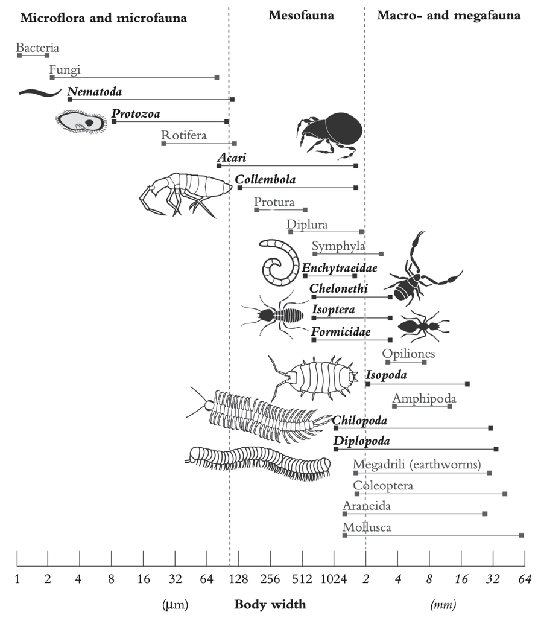

Clasificación de la fauna del suelo por ancho del cuerpo (Nielsen, 2019).

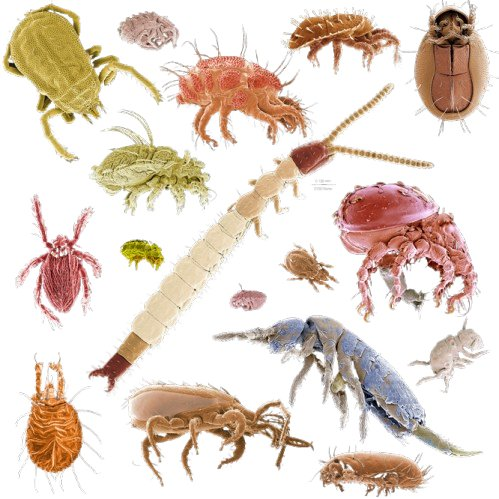

Algunos representantes de la mesofauna.

### Ácaros (*Acari*)

- Parientes de arañas y escorpiones; cuerpo sin regiones visibles;
- Los adultos tienen 4 pares de patas; la larva, solo 3;
- Tienen la dieta más variada del grupo: hongos, materia en descomposición y otros animales;
- Hay unas 50.000 especies descritas, pero podrían ser más de un millón;
- Los oribátidos llegan a 100.000 individuos por m² en algunos bosques.

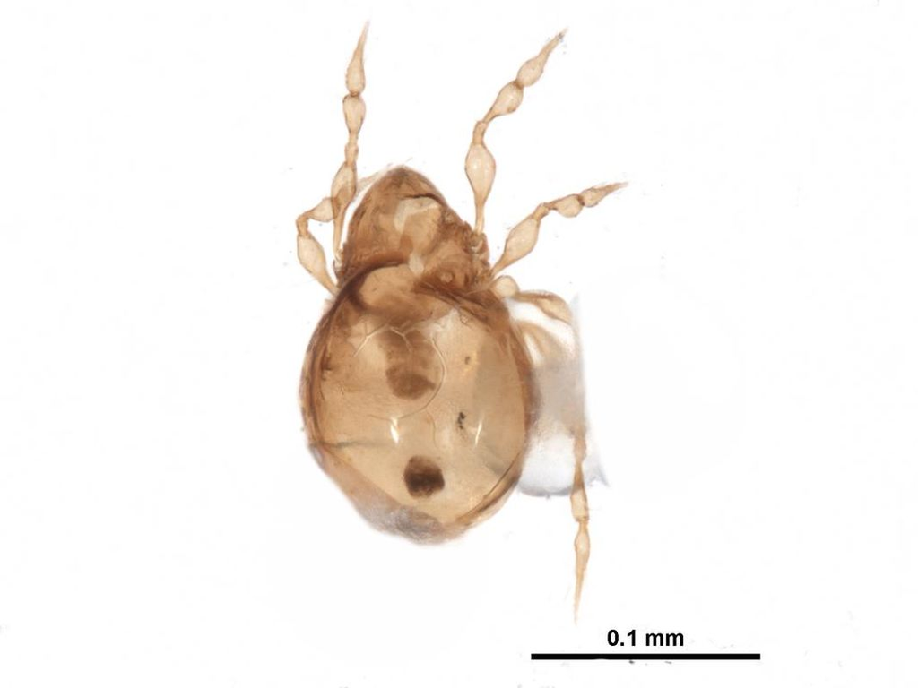

Ácaro del suelo.

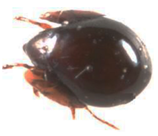

Ácaro de la familia Galumnidae. Foto: Helisama Colín Martínez.

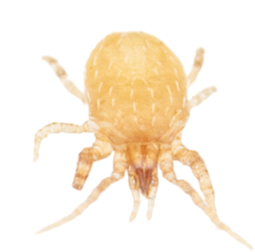

*Stratiolaelaps scimitus*, ácaro depredador.

### Colémbolos (*Collembola*)

- **Fúrcula:** una “cola” que funciona como catapulta para escapar de los depredadores;
- **Colóforo:** tubo ventral que los fija al sustrato (del griego *colla*, pegamento);
- Comen hongos y materia orgánica muerta, y estimulan a los microbios descomponedores;
- Son ametábolos (no tienen metamorfosis) y mudan durante toda la vida; muchos se reproducen sin machos;
- Son muy sensibles a la humedad y a la temperatura.

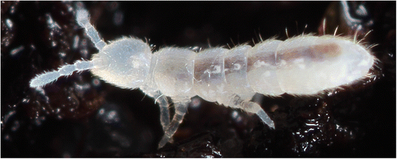

*Folsomia candida*, especie partenogenética.

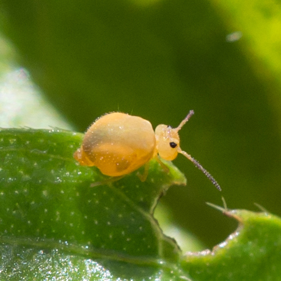

*Bourletiella arvalis*, colémbolo globoso.

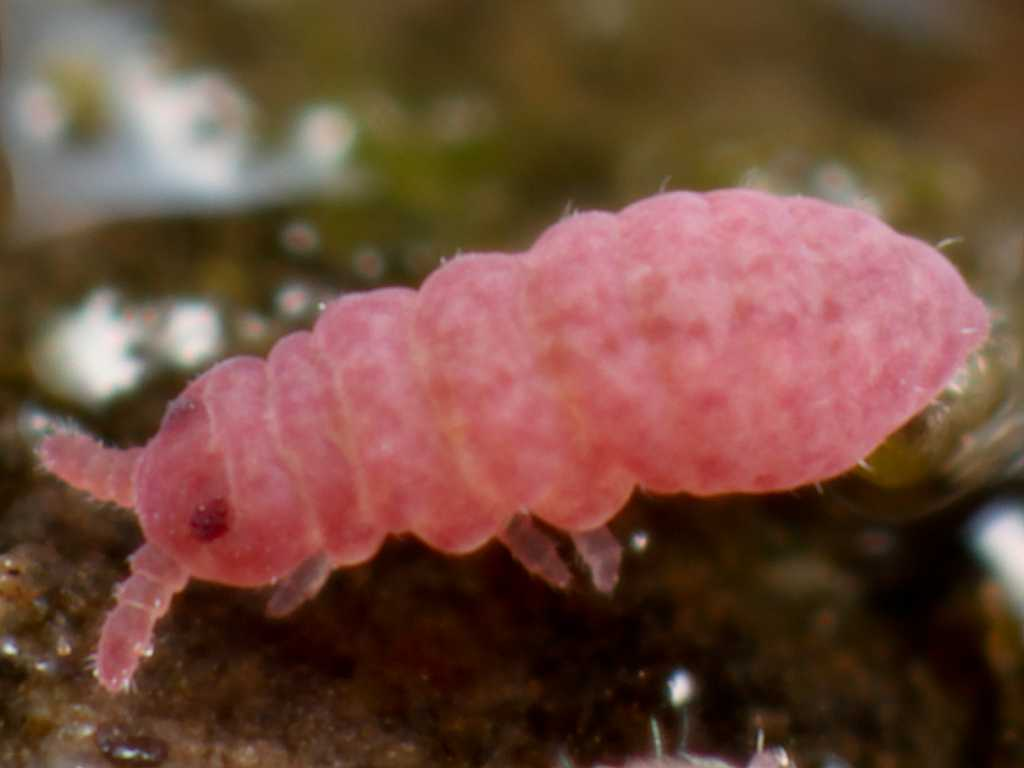

*Brachystomella parvula*.

Fuentes: Baretta et al. (2011); Toma et al. (2017).

El salto de los colémbolos, en cámara lenta (New Scientist), basado en el estudio de Ortega-Jimenez et al. (2022):

[video not shown]

### El resto de la mesofauna

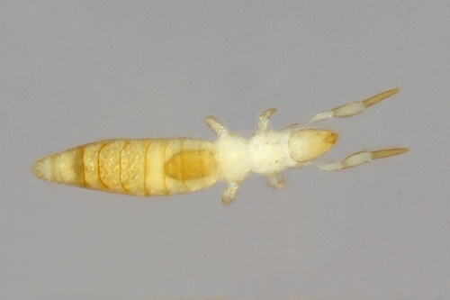

**Proturos.** Sin ojos ni antenas; usan el primer par de patas como sensor.

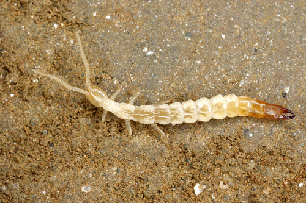

**Dipluros.** Dos “colas”; en pinza, depredadores; filiformes, detritívoros.

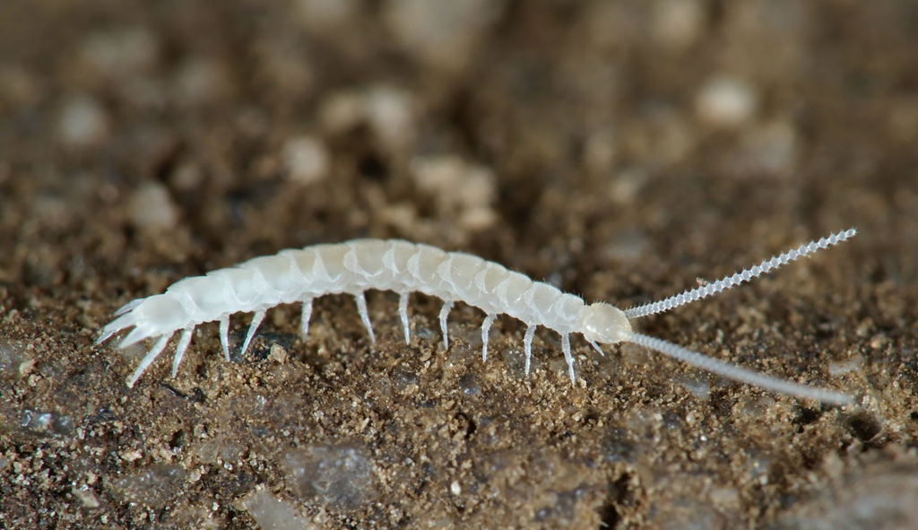

**Sínfilos.** Miriápodos con 12 pares de patas; tienen órgano de Tömösváry y producen seda por los cercos.

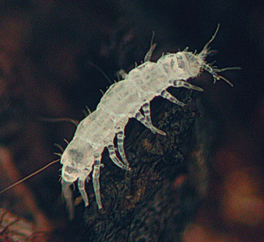

**Paurópodos.** Sin corazón ni sistema respiratorio; respiran por la piel.

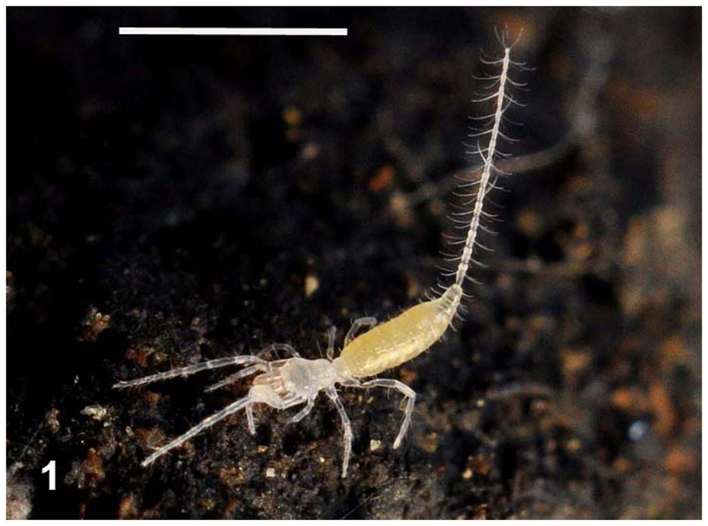

**Palpígrados.** Arácnidos ciegos y blanquecinos, muy poco estudiados.

Los enquitreidos, o “lombrices blancas”, también forman parte de la mesofauna. Dependen de humedad, pH neutro o levemente ácido y suelo no compactado, y pueden llegar a 146.000 individuos por m<sup>2</sup> en bosques templados (Toma et al., 2017).

### Algunas curiosidades

- Una cucharadita de suelo contiene más organismos vivos que personas en el mundo (FAO et al., 2020).
- Un gramo de suelo puede contener hasta mil millones de células de bacterias, de decenas de miles de taxones, y hasta 200 metros de hifas de hongos (FAO et al., 2020).
- El suelo alberga más del 25 % de la biodiversidad del planeta (FAO et al., 2020).
- Aunque puede haber 100.000 ácaros en un metro cuadrado, todos juntos pesan apenas unos 2 g (FAO et al., 2020).
- La biomasa de toda la fauna del suelo es menos del 4 % de la biomasa microbiana, pero la fauna aumenta la descomposición de la hojarasca en un 27 % en promedio (FAO et al., 2020).

## 2. ¿Qué hacen sus organismos?

### Grupos según lo que comen

La fauna del suelo se divide en dos grandes grupos según su alimentación: los que comen materia muerta (**saprófagos**) y los que comen tejidos vivos (**biófagos**) (Baretta et al., 2011).

Grupos tróficos de la fauna del suelo (Baretta et al., 2011; Toma et al., 2017).

| Grupo | Subgrupo | Qué comen | Ejemplos |
| --- | --- | --- | --- |
| **Saprófagos** (materia muerta) | Detritívoros | Restos vegetales en varios estados de descomposición | diplópodos, isópodos |
|  | Coprófagos | Excrementos de otros animales | escarabajos, lombrices |
|  | Cadavéricolas | Animales muertos | larvas de insectos |
| **Biófagos** (tejidos vivos) | Fitófagos | Raíces y tejidos vegetales vivos | sínfilos, algunos nematodos |
|  | Fungívoros y microbívoros | Hifas, esporas, bacterias y pequeños organismos | colémbolos, muchos ácaros |
|  | Depredadores | Otros animales vivos, que matan rápidamente | ácaros gamásidos, arañas |
|  | Parásitos | Otros animales vivos, que matan lentamente |  |

La fauna del suelo forma una red trófica completa, y por eso una misma práctica de manejo puede favorecer a un grupo y perjudicar a otro.

### Microbios y fauna no actúan de la misma manera!

Las actividades de la fauna y de los microorganismos están muy relacionadas, pero cada grupo trabaja de forma distinta (Baretta et al., 2011):

- **Microorganismos:** acción química. Hacen la mayor parte de la descomposición de una hoja y la transformación de las sustancias húmicas;
- **Fauna:** acción química y física. Reduce el tamaño de los residuos, mezcla partículas, forma poros y estabiliza agregados;
- **Respiración:** todos los organismos aeróbicos liberan CO<sup>2</sup>, pero la mayor parte del CO<sup>2</sup> del suelo proviene de las raíces y de los microbios. El humus se forma sobre todo por acción microbiana (Lepsch, 2011);
- **Lombrices:** tragan grandes cantidades de suelo; sus enzimas y excrementos contribuyen a formar humus y mejoran la estructura y la aireación (Lepsch, 2011).

### Las funciones de la fauna

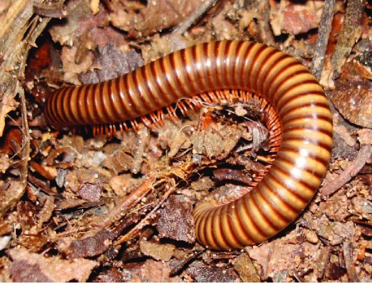

Fragmentan la hojarasca y abren superficie a los microbios.

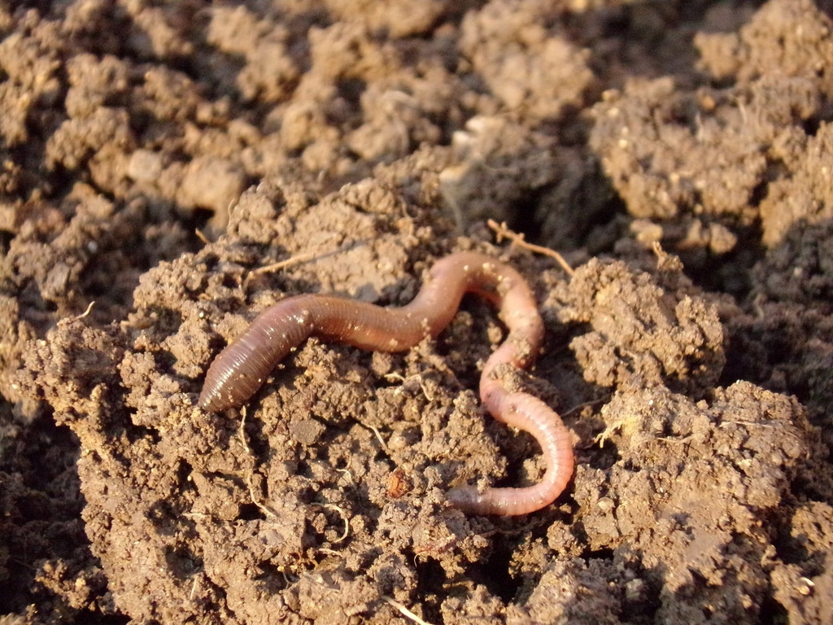

Redistribuyen materia orgánica y nutrientes hacia abajo.

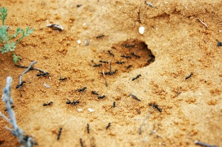

Construyen poros, galerías que mejoran la aireación, la infiltración y el paso de raíces.

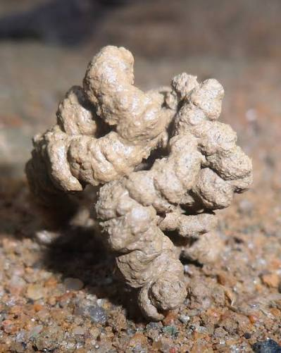

Agregan: sus excrementos estabilizan agregados frente al agua y el viento.

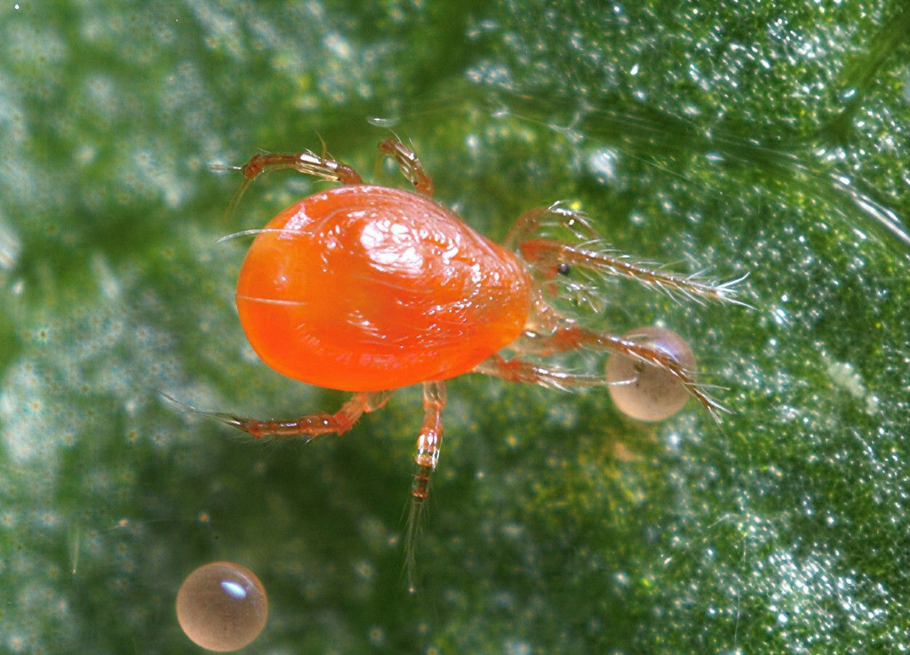

Regulan microbios, plagas y patógenos.

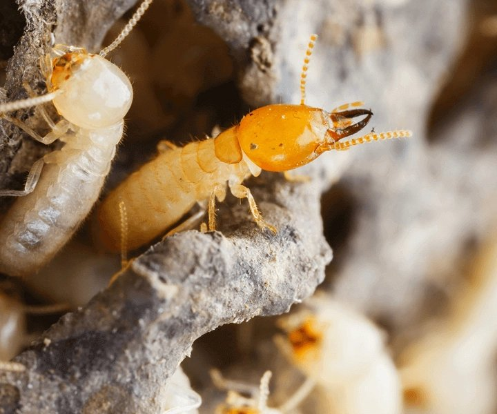

Degradan celulosa, lignina y algunas sustancias tóxicas.

Fuente: Baretta et al. (2011).  
Las galerías y poros los construye sobre todo la macrofauna (lombrices, termitas, hormigas); la mesofauna actúa más en la fragmentación, en la regulación de hongos y bacterias y en la dispersión de esporas.

### El otro lado de la moneda

Cuando se habla de microorganismos, lo primero que se asocia son las enfermedades. Esa percepción tiene una base histórica, porque los primeros microorganismos estudiados estaban relacionados con enfermedades humanas (Dionísio et al., s. f.). En el suelo también viven organismos que causan problemas, y la biota del suelo puede provocar pérdidas importantes en los cultivos (FAO et al., 2020). Algunos ejemplos:

- *Spongospora subterranea*, un protista del suelo que causa lesiones en los tubérculos y agallas en las raíces de la papa, y cuyas esporas persisten en el suelo por muchos años (FAO et al., 2020);
- nematodos que parasitan raíces y sínfilos que dañan raíces de cultivos;
- *Bacillus anthracis*, bacteria nativa del suelo que parasita al ganado y causa el ántrax (Dionísio et al., s. f.).

Sin embargo, los organismos perjudiciales son pocos comparados con los benéficos, que descomponen residuos, reciclan nutrientes y tienen usos agrícolas, industriales y farmacéuticos (Dionísio et al., s. f.). Además, la propia biota del suelo ayuda a controlar a los patógenos:

- en un suelo sano y sin perturbar, las bacterias no patógenas suelen superar en competencia a las patógenas, y las actinobacterias, como *Streptomyces*, producen antibióticos que inhiben a los patógenos de plantas (FAO et al., 2020);
- en laboratorio, algunos colémbolos prefieren comer hongos patógenos antes que hongos micorrízicos, y pueden reducir enfermedades de raíz en cereales; en el campo, el efecto depende de su densidad (FAO et al., 2020);
- las lombrices pueden regular patógenos de plantas y el desarrollo de enfermedades (FAO et al., 2020).

El suelo también nos protege a nosotros. De él se aislaron los primeros microorganismos productores de antibióticos: la penicilina, de hongos; la neomicina, de bacterias; y la estreptomicina, de actinobacterias (Moreira y Siqueira, 2006, citado en Dionísio et al., s. f.). Y mucho antes de la industria farmacéutica ya había contacto con ellos: se encontró tetraciclina en esqueletos de la antigua Nubia, en Sudán, de los años 350 a 550 d. C. (Nelson et al., 2010, citado en FAO et al., 2020).

### Distribución

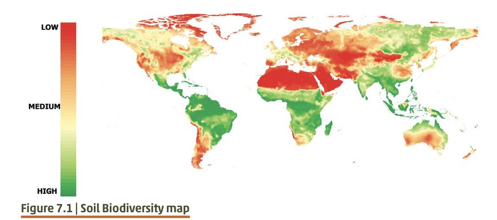

Mapa mundial de biodiversidad potencial del suelo (FAO et al., 2020).

El número de organismos del suelo varía según las condiciones ambientales y es mucho mayor en ecosistemas naturales que en suelos agrícolas. Un suelo hoy deforestado y cultivado se formó bajo la influencia de muchos otros organismos, además de los que lo habitan ahora. Esa influencia es mayor en los trópicos húmedos, porque en latitudes templadas el invierno reduce el número de especies (Lepsch, 2011).

La fauna vive cerca de la superficie: bajo eucalipto, el 97,7 % de los individuos estaba en los primeros 10 cm del suelo (Soares y Costa, 2001, citado en Baretta et al., 2011). La temperatura regula su metabolismo y, junto con la humedad, decide dónde viven y cuándo están activos. También dependen de la materia orgánica, la porosidad, la cobertura vegetal, el pH, la textura y el manejo (Dionísio & Signor, 2016; Lavelle & Spain, 2001). Por eso cualquier práctica que afecte la superficie, como arar, quemar, dejar el suelo desnudo o cubrirlo con rastrojo, cambia rápidamente la fauna.

**Curiosidad**: algunos microorganismos viven en condiciones extremas, como *Deinococcus radiodurans*, muy resistente a la radiación, y *Desulforudis audaxviator*, que vive a aproximadamente 3,2 km de profundidad!

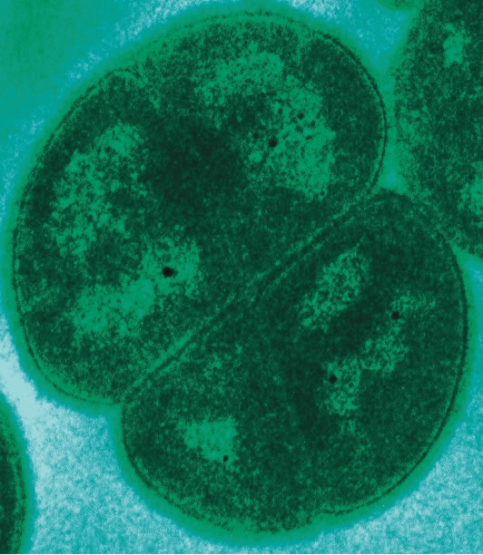

*Deinococcus radiodurans* (BBC, 2014).

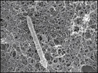

*Desulforudis audaxviator* (BBC, 2008).

## 3. ¿Cómo sabemos si el suelo está sano?

### ¿Que es la salud del suelo?

- Es la capacidad de un suelo de funcionar, en un momento dado, como un sistema vivo vital (Doran & Zeiss, 2000).
- Un suelo sano está en buen estado químico, físico y biológico (Parlamento Europeo y Consejo de la Unión Europea, 2025).
- Un suelo sano está bien agregado, de modo que el aire y el agua puedan penetrarlo, y limpio, sin sustancias tóxicas (Primavesi, 2016).
- La salud de un suelo se mide comparándolo con lo que ese tipo de suelo podría ser (Clesse et al., 2026):

$$\text{Salud del suelo} = \text{estado funcional actual} - \text{estado funcional de referencia}$$

Un valor positivo indica un suelo más sano que su referencia; cero = similar; y negativo = menos sano.

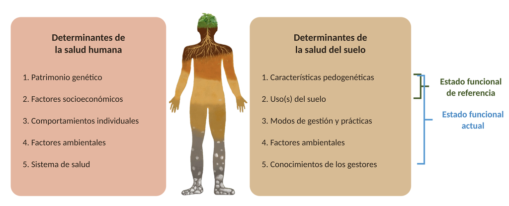

Determinantes de la salud humana y de la salud del suelo. Adaptado de Fausak et al. (2024), en Clesse et al. (2026).

### Lo que vacía el suelo de vida

[figure not shown]

Suelo desnudo: más calor y menos alimento en superficie.

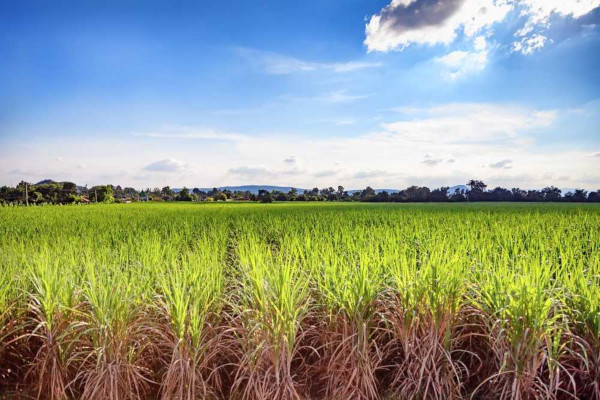

Monocultivo: pocos recursos y refugios; dominan pocas especies.

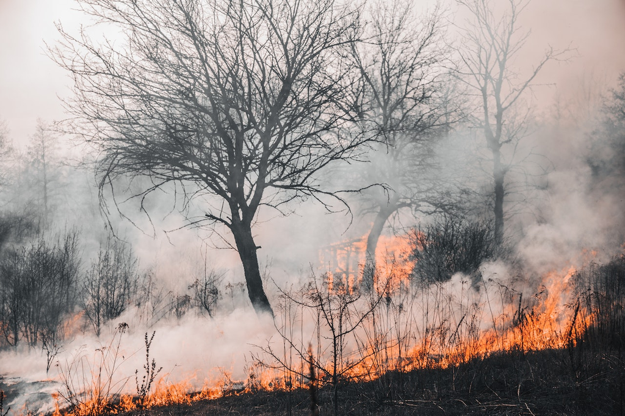

Desmonte con fuego: menos abundancia y diversidad.

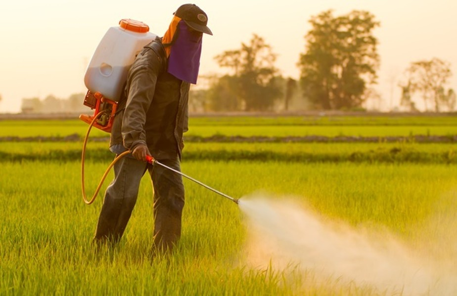

Plaguicidas: matan huevos y larvas y afectan a los ácaros desde el primer año.

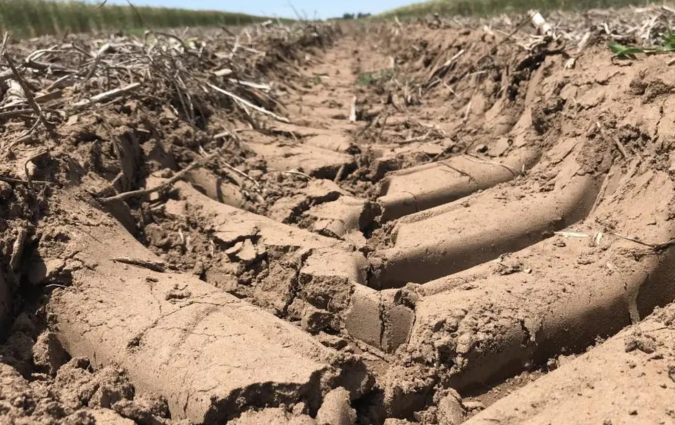

Compactación: menos poros, por donde la mesofauna ya no puede moverse.

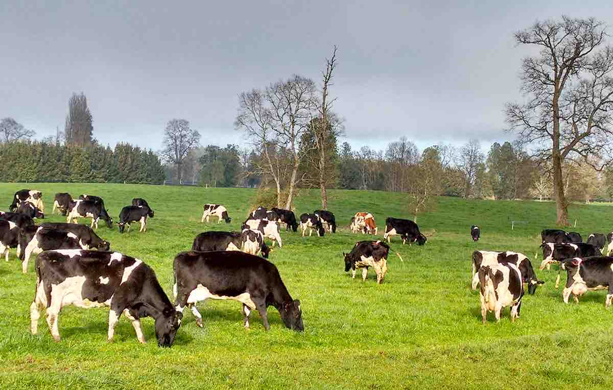

Praderas degradadas: menor riqueza de grupos.